# Physical and numerical modeling of cross-flow turbines

[figure not shown]

by Pete Bachant

Advisor: Martin Wosnik

## What is a cross-flow turbine?

[figure not shown]

- Axis perpendicular to flow
- Some success in onshore wind
- Surpassed by HAWTs (AFTs) →
  - Exaggerated power ratings
  - Fatigue issues

[figure not shown]

Left: Photo by Paul Gipe. All rights reserved. Upper right: Courtesy of Vestas Wind Systems A/S. Lower right: From Murray and Barone (2011).

## Marine hydrokinetics: ORPC

#### TidGen, Cobscook Bay, ME:

[figure not shown]

#### RivGen, Igiugig, AK:

[figure not shown]

From orpc.co.

## Wind turbine arrays: Caltech FLOWE

Closely spaced VAWTs may achieve higher power output per unit land area compared to HAWTs. Note the rotors shown here are also high solidity.

[figure not shown]

From flowe.caltech.edu.

## Blade element theory

Assume kinematics and dynamics act on blade section at one point.

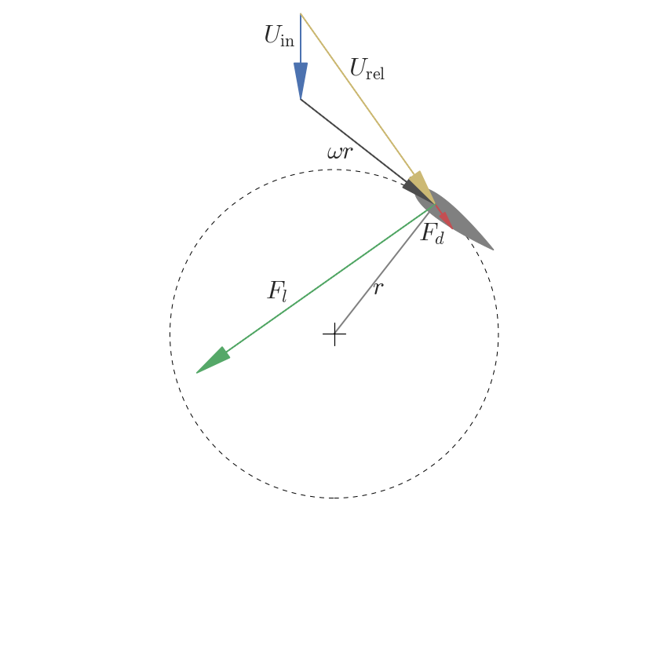

```python
import warnings
warnings.filterwarnings("ignore")
os.chdir(os.path.join(os.path.expanduser("~"), "Google Drive", "Research", "CFT-vectors"))
import cft_vectors
fig, ax = plt.subplots(figsize=(15, 15))
fontsize = plt.rcParams["font.size"]
with plt.rc_context({"font.size": 1.5*fontsize}):
    cft_vectors.plot_diagram(fig, ax, theta_deg=52, axis="off", label=True)
os.chdir(talk_dir)
```

## Blade element theory

[video not shown]

In an idealized case, CFT is unsteady, often $\alpha_\max \gt \alpha_{\mathrm{ss}}$. Not so for AFT.

## Quantifying unsteadiness

Reduced frequency:

$$ k = \frac{\omega c}{2 U_\infty} = \frac{\lambda c}{2R} $$$$ \lambda = \frac{\omega R}{U_\infty} $$

Unsteady effects significant for $k > 0.05$, dominant for $k \ge 0.2$ [1].

[output not shown]

MHK rotor blades see approximately one order of magnitude higher torque vs. wind.

[1] Leishman (2006) "Principles of Helicopter Aerodynamics", Cambridge.

## Research objectives

1. Produce model validation datasets for higher solidity CFTs
2. Investigate near-wake, especially recovery
   - Relevant to array design
3. Evaluate Navier–Stokes based models (blade-resolved and parameterized) for predicting performance and wake characteristics
   - Lower fidelity models fail for higher $c/R$
   - Computing power has advanced tremendously since the Darrieus VAWT R&D

## Turbine test bed

Automated turbine testing in the UNH tow tank

[figure not shown]

## Test bed instrumentation

[figure not shown]

## Wake measurement instrumentation

- Nortek Vectrino+ acoustic Doppler velocimeter (ADV)
- $y$–$z$ traversing carriage with motion control integration

[figure not shown]

## Automation

[figure not shown]

## Operation

[video not shown]

## UNH-RVAT baseline experiments

[figure not shown]

- Simple geometry
- NACA 0020 foils
- High solidity $c/R = 0.28$
- $U_\infty = 1$ m/s
- Characterize performance
- Near-wake dynamics
- Open dataset

Bachant, P., and Wosnik, M. (2015) "Characterising the near-wake of a cross-flow turbine", Journal of Turbulence, 16, 392–410.

Bachant, P., and Wosnik, M. (2014) "UNH-RVAT baseline performance and near-wake measurements: Reduced dataset and processing code", Figshare, DOI: 10.6084/m9.figshare.1080781.

## UNH-RVAT baseline performance

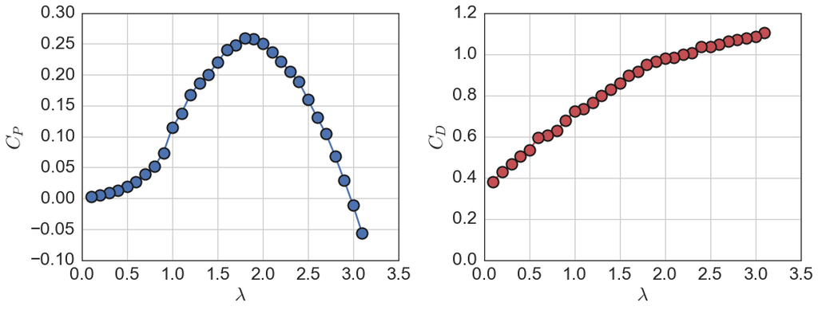

```python
# Generate figures from the experiments by their own methods

os.chdir("C:/Users/Pete/Research/Experiments/RVAT baseline")
import pyrvatbl.plotting as rvat_baseline

fig, (ax1, ax2) = plt.subplots(figsize=(15, 6), nrows=1, ncols=2)
rvat_baseline.plot_cp(ax1)
rvat_baseline.plot_cd(ax2, color=sns.color_palette()[2])
fig.tight_layout()
os.chdir(talk_dir)
```

$\lambda = \frac{\omega R}{U_\infty}$ $C_P = \frac{P_\mathrm{mech}}{\frac{1}{2}\rho A_\mathrm{f} U_\infty^3}$ $C_D = \frac{F_\mathrm{drag}}{\frac{1}{2}\rho A_\mathrm{f} U_\infty^2}$

Note: Overall rotor drag (sometimes called thrust) coefficient $C_D$ is different from blade element drag coefficient $C_d$.

## Baseline wake measurements $(x/D=1)$

[figure not shown]

## UNH-RVAT baseline wake characteristics

[figure not shown]

Unique mean "doublet" flow created by blade tip vortices inducing vertical velocity towards $x$–$y$ center plane.

## Mean momentum transport

Rearrange RANS to isolate streamwise partial derivative:

$$ \begin{split} \frac{\partial U}{\partial x} = \frac{1}{U} \bigg{[} & - V\frac{\partial U}{\partial y} - W\frac{\partial U}{\partial z} \\ & -\frac{1}{\rho}\frac{\partial P}{\partial x} \\ & - \frac{\partial}{\partial x} \overline{u'u'} - \frac{\partial}{\partial y} \overline{u'v'} - \frac{\partial}{\partial z} \overline{u'w'} \\ & + \nu\left(\frac{\partial^2 U}{\partial x^2} + \frac{\partial^2 U}{\partial y^2} + \frac{\partial^2 U}{\partial z^2} \right) \bigg{]} \end{split} $$

## Mean momentum transport

Weighted averages at $x/D=1$:

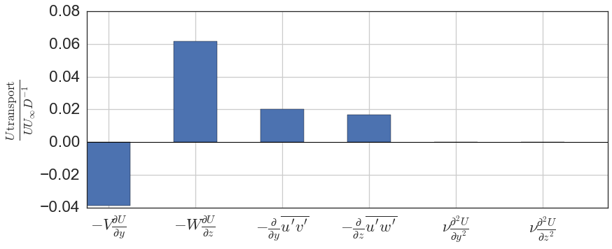

```python
os.chdir("C:/Users/Pete/Research/Experiments/RVAT baseline")
import pyrvatbl.plotting as rvat_baseline

rvat_baseline.plotwake("mombargraph", scale=1.8, barcolor=None)
plt.grid(True)
```

Mean advection in AFT wake due to axisymmetric swirl would cancel itself out.

## UNH-RVAT Reynolds number dependence

Are our results relevant to full scale?

$$ Re_l = \frac{Ul}{\nu} $$

How inexpensive (small, slow) can experiments get?

Bachant, P., and Wosnik, M. (2016) "Effects of Reynolds Number on the Energy Conversion and Near-Wake Dynamics of a High Solidity Vertical-Axis Cross-Flow Turbine", Energies, 9.

Bachant, P., and Wosnik, M. (2016) "UNH-RVAT Reynolds number dependence experiment: Reduced dataset and processing code", Figshare, DOI: 10.6084/m9.figshare.1286960.

## UNH-RVAT Reynolds number dependence

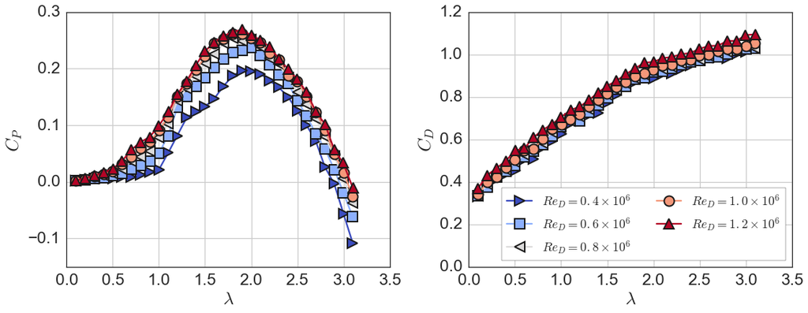

```python
os.chdir(rvat_re_dep_dir)
import pyrvatrd.plotting as rvat_re_dep

fig, (ax1, ax2) = plt.subplots(figsize=(16, 6.5), nrows=1, ncols=2)
rvat_re_dep.plot_perf_curves(ax1, ax2)
fig.tight_layout()
os.chdir(talk_dir)
```

Note effects of stall delay at lower $\lambda$, where angle of attack amplitude is greater.

## Reynolds number dependence at $\lambda = 1.9$

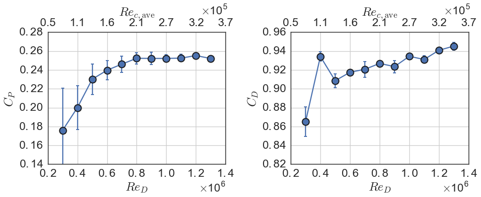

```python
os.chdir(rvat_re_dep_dir)
import pyrvatrd.plotting as rvat_re_dep

fontsize = plt.rcParams["font.size"]

with plt.rc_context({"axes.formatter.use_mathtext": True, "font.size": fontsize*1.65/1.5}):
    fig, (ax1, ax2) = plt.subplots(figsize=(14, 6), nrows=1, ncols=2)
    rvat_re_dep.plot_perf_re_dep(ax1, ax2, errorbars=True, label_subplots=False)
    fig.tight_layout()

os.chdir(talk_dir)
```

$$ Re_{c,\mathrm{ave}} = \lambda U_\infty c / \nu $$

Threshold corresponds to blade boundary layer transition to turbulence, which delays separation to higher angles of attack.

$$ Fr = \frac{U_\infty}{\sqrt{gh_{\mathrm{tip}}}} = 0.1 \text{ to } 0.5 $$

## Wake transport totals

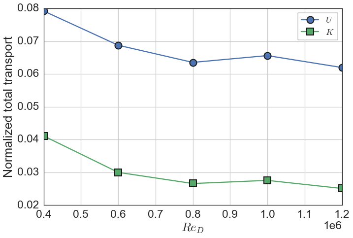

```python
os.chdir(rvat_re_dep_dir)
import pyrvatrd.plotting as rvat_re_dep

fig, ax = plt.subplots()
with plt.rc_context({"axes.formatter.use_mathtext": True}):
    rvat_re_dep.plot_wake_trans_totals(ax)
fig.tight_layout()
```

Similar threshold $Re$ as for $C_P$ → Low $Re$ physical model array studies may overpredict power of downstream turbines

## DOE/SNL Reference Model 2 (RM2) experiments

DOE Reference Models: Open designs for standardized development and validation

Measured performance, $Re$-dependence, near-wake, strut drag, with 1:6 scale tapered-H rotor: NACA 0021 profiles, $c/R = 0.07$–$0.12$

[figure not shown]

Unique geometry for testing predictive robustness

Bachant, P., Gunawan, B., Wosnik, M., and Neary, V.S. (2016) "UNH RM2 tow tank experiment: Reduced dataset and processing code", Figshare, DOI: 10.6084/m9.figshare.1373899.

## RM2 performance curves

[figure not shown]

Higher peak $C_P = 0.37$ vs. UNH-RVAT's $0.26$.

## RM2 performance $Re$-dependence at $\lambda = 3.1$

[figure not shown]

Retains weak $Re$-dependence → lower $c/R$ or virtual camber

## RM2 near-wake

### $Re_D = 1.1 \times 10^6$, $x/D=0.93$, $\lambda=3.1$

[figure not shown]

Similar wake recovery proportions, but lower overall compared to UNH-RVAT → potential trade-off vs. higher $C_P$

## UNH-RVAT blade-resolved RANS

- Simulate baseline with OpenFOAM

[figure not shown]

- Need to resolve the boundary layer
- Separation
- Transition?
- Turbulence models (eddy viscosity)
- $k$–$\omega$ SST
- Spalart–Allmaras
- 2-D: $\sim 0.1$ CPU hours per simulated second
- 3-D: $\sim 10^3$ CPU hours per simulated second
- HPC required: significant investment
- 192 cores on SNL Red Mesa cluster

## Mesh topology overview

[figure not shown]

## Near-wall blade mesh

[figure not shown]

$$ y^+ = u^* y / \nu \sim 1 $$$$ u^*=\sqrt{\tau_w / \rho} $$

## Verification (2-D)

[figure not shown]

Spalart–Allmaras model showed more well-behaved grid convergence. Relative minimum chosen for SST $\Delta t$. $N_x = 70$ chosen for both models.

## Performance predictions

[figure not shown]

Overprediction by 2-D simulations consistent with the literature.

## Near-wake mean velocity

#### 3-D Spalart–Allmaras

[figure not shown]

#### Experiment

[figure not shown]

## Near-wake mean velocity

#### 3-D SST

[figure not shown]

#### Experiment

[figure not shown]

## Near-wake momentum transport

[figure not shown]

Weighted sums for CFD computed over entire domain at $x/D=1$

## Actuator line modeling

- Developed by Sorensen and Shen (2002)
- Blade element method coupled with Navier–Stokes
- Save computational resources
  - No finely resolved blade boundary layers
  - No complicated meshing
  - No mesh motion
- Current state-of-the-art for HAWT array modeling
- Has only been investigated with LES for a 2-D low-$Re$ CFT by Shamsoddin and Porte-Agel (2014)
  - No performance predictions reported
  - Closed source

## ALM blade element discretization

[figure not shown]

## Computing blade loading

Inflow velocity from Navier–Stokes solver rather than via simple momentum, potential flow (vortex method).

$$ F_l = \frac{1}{2} \rho A_p C_l | U_{\mathrm{rel}} |^2 \, \, \, \, \, \, \, \, \, F_d = \frac{1}{2} \rho A_p C_d | U_{\mathrm{rel}} |^2 $$

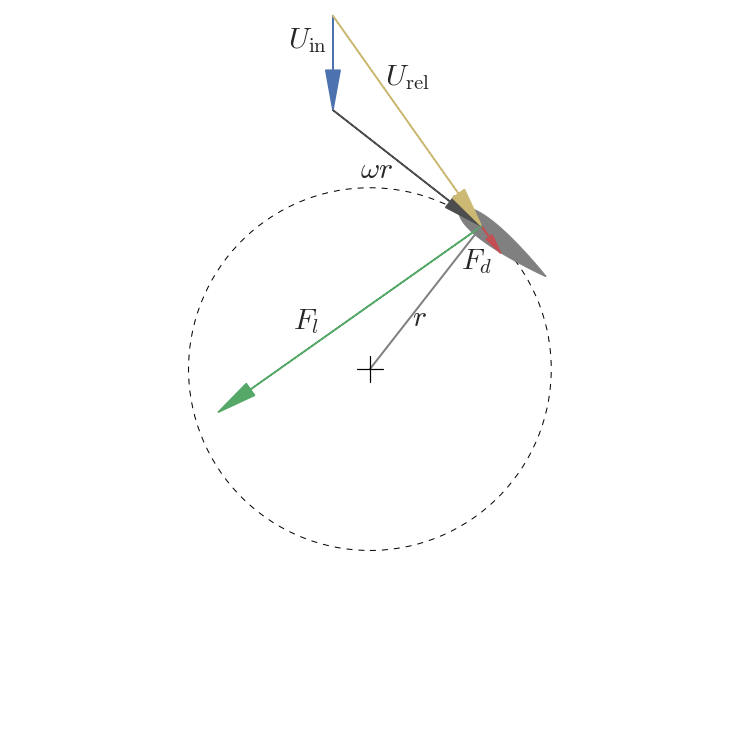

```python
import warnings
warnings.filterwarnings("ignore")
os.chdir(os.path.join(os.path.expanduser("~"), "Google Drive", "Research", "CFT-vectors"))
import cft_vectors
fig, ax = plt.subplots(figsize=(13, 13))
fontsize = plt.rcParams["font.size"]
with plt.rc_context({"font.size": 1.4*fontsize}):
    cft_vectors.plot_diagram(fig, ax, theta_deg=52, axis="off", label=True)
os.chdir(talk_dir)
```

## Dynamic stall modeling

[figure not shown]

From Leishman and Beddoes (1989)

Leishman–Beddoes semi-empirical dynamic stall model based on lags to angle of attack, separation point, vortex lift, replicating "hysteresis loop."

## Flow field coupling

AL force added to Navier–Stokes as body force source term:

$$ \frac{\partial \vec{u}}{\partial t} + \vec{u} \cdot \nabla \vec{u} = -\frac{1}{\rho}\nabla p + \nabla^2 \vec{u} + \boxed{\vec{f}} $$

Force is smoothed outwards with a spherical Gaussian function:

[figure not shown]

Gaussian width mainly determined by local mesh size: $\approx 2 \Delta x$ (Troldborg, 2008) $\approx 2 \times 2 \sqrt[3] V_{\mathrm{cell}}$

## Implementation

OpenFOAM extension library using `fvOptions` generic mechanism for adding sources at run time:

```
// Solve the Momentum equation

tmp<fvVectorMatrix> UEqn
(
    fvm::ddt(U)
  + fvm::div(phi, U)
  + turbulence->divDevReff(U)
 ==
    fvOptions(U)
);
```

Leverage existing solvers, parallelization, turbulence models. *No wheel reinvention.*

Developed openly on GitHub: https://github.com/turbinesFoam/turbinesFoam

## UNH-RVAT and RM2 actuator line simulations

- Leishman–Beddoes DS model modified by Sheng et al. (2008)
- Flow curvature correction from Goude (2012)
- Lifting line based end effects model (not used for RM2)
- Added mass correction from Strickland et al. (1981)
- NACA 0021 static coefficients from Sheldahl and Klimas (1981)
  - Major weakness of BE methods: Need static data, which is surprisingly hard to find
- Standard $k$–$\epsilon$ RANS model (eddy viscosity)

## ALM mesh

Similar domain and BCs as 3-D blade-resolved case

[figure not shown]

$\sim 10^4$ lower computational effort with 3-D RANS compared to blade-resolved → Easily run on laptop

## ALM verification

#### UNH-RVAT

[figure not shown]

#### RM2

[figure not shown]

## ALM performance

#### UNH-RVAT

[figure not shown]

#### RM2

[figure not shown]

## UNH-RVAT near-wake mean velocity

### ALM inside $k$–$\epsilon$ RANS

[figure not shown]

Low order modeling resolves less detail, but retains asymmetric streamwise deficit, counter-clockwise mean swirl.

## UNH-RVAT near-wake momentum transport

### ALM inside $k$–$\epsilon$ RANS

[figure not shown]

Matches trends relatively well except for cross-stream advection

## Actuator disk mean velocity at $x/D= 1$

Common streamwise force parameterization based on $C_D$

[figure not shown]

Small negative advection in all directions, very low turbulence, positive pressure gradient effect → ALM generates better IBCs for wake evolution

## UNH-RVAT ALM LES

Default Smagorinsky sub-grid scale model

[video not shown]

Computational expense up by $\sim 10^2$, still $\sim 10^2$ lower than BR RANS

## UNH-RVAT near-wake

### ALM inside default Smagorinsky LES

[figure not shown]

Finer mesh reduces diffusion of counter-clockwise mean swirl

## UNH-RVAT near-wake momentum transport

### ALM inside default Smagorinsky LES

[figure not shown]

Small negative turbulence effects → SGS model and vortex breakdown

## Conclusions (I)

- Developed an automated turbine test bed and two 1 m scale turbine models
  - High solidity UNH-RVAT and medium/low solidity RM2
- Produced 3 open performance and near-wake datasets
- Near-wake streamwise recovery dominated by vertical advection
- $Re$-independence at $Re_D \sim 10^6$ or $Re_c \sim 10^5$
  - Guidelines for physical model scaling
- Blade-resolved RANS *can* postdict *some* results in 3-D
  - Uncertainty w.r.t. turbulence model choice
  - Too expensive for arrays

## Conclusions (II)

Developed new open-source ALM library for OpenFOAM

- Fills gap between low- and high-fidelity modeling
- Retains Navier–Stokes description
- Reduce computational effort (not including meshing):

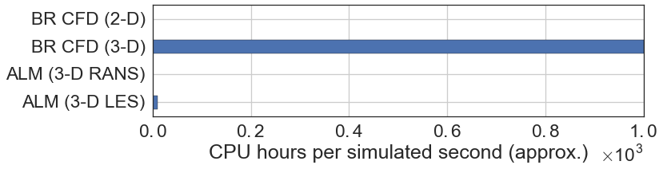

```python
import pandas as pd
data = pd.Series()
data["ALM (3-D LES)"] = 10.0
data["ALM (3-D RANS)"] = 0.1
data["BR CFD (3-D)"] = 10**3
data["BR CFD (2-D)"] = 0.1

with sns.plotting_context(font_scale=3) \
        and plt.rc_context({"axes.formatter.limits": (-1, 1),
                            "axes.formatter.use_mathtext": True}):
    fig, ax = plt.subplots(figsize=(11, 2.5))
    data.plot(ax=ax, kind="barh", logy=False, rot=0)
    ax.set_xlabel("CPU hours per simulated second (approx.)")
plt.show()
```

- Performance predictions close to 3-D B-R RANS at optimal $\lambda$
- Wake predictions much better than AD, except low turbulent transport in LES
- Promising for future development → Improves with turbulence modeling

## Future work

- 2-D blade-resolved RANS for relative optimization
- Investigate wake further downstream
  - Compute streamwise derivatives and overall recovery rate
  - Compare with blade-resolved CFD and ALM
- Vortex breakdown (PIV?) and SGS model selection
- ALM validation against multi-CFT (small array) experiments

## Future work: VAT with free surface

[video not shown]

## Future work: Axial-flow turbine

Extensive AFT validation case by Krogstad and Adaramola (2012)

[video not shown]

## Acknowledgments

[figure not shown]